# Project 3 - Data Visualization of Ford Go-Bike System

## Bivariate Data Analysis

#### Which day of the week has the most average trips duration?

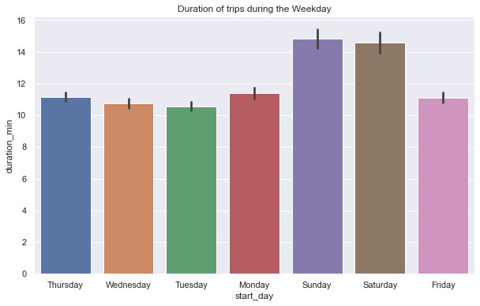

#### Which the trip duration of each age group?

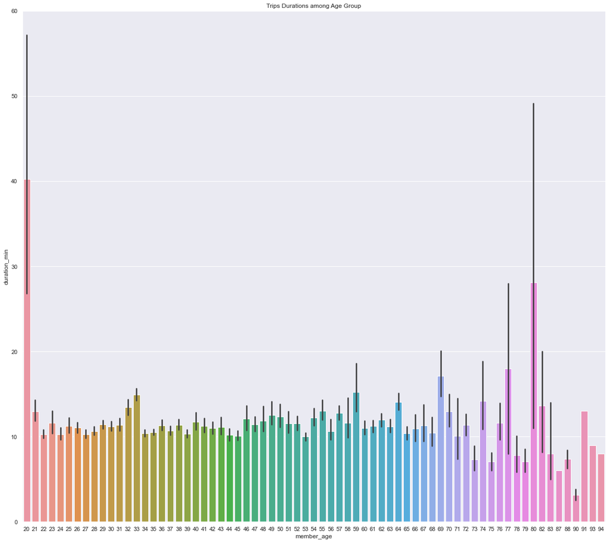

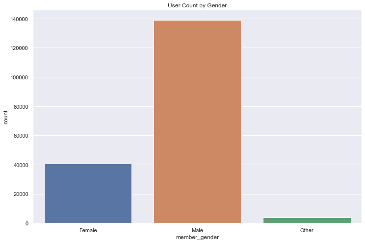

Form the chart, most of the users are males

#### What is the age range of different user types?

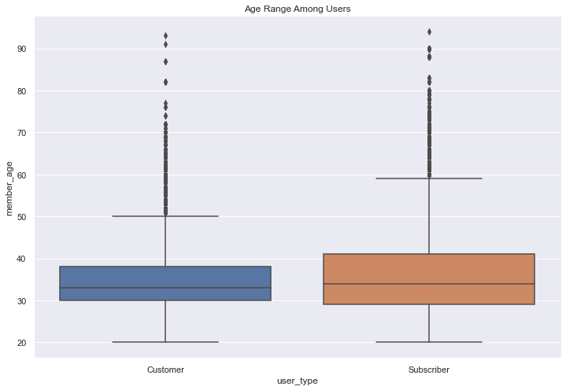

From the chart above, most the customers are between the ages of 30 and 39. While the age range of majority of subscribers is 30 and 41 years.

#### What is the age range of different genders?

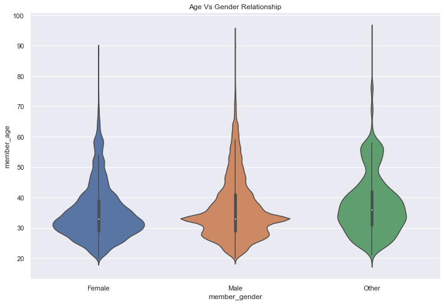

Both male and females age ranges have the same median age

## Multivariate Data Analysis

> - Create a graph consisting of tree or more variables to investigate the dataset

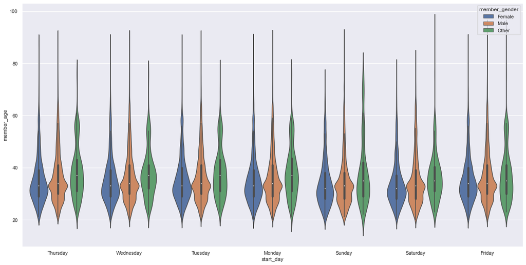

"Other" gender have the largest median accross board.

#### Which gender have the most average trip duration among weekdays

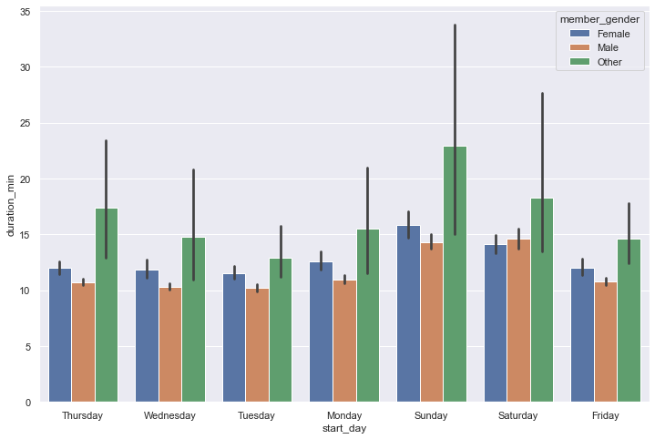